# Modelação Bayesiana

#### Estimação seguida com FA criadas no próprio modelo

Agora faremos uma abordagem full SEM que consiste em fazer a modelação de todos os construtos e depois fazer a modelação SEM. Vamos replicar na exatidão o que é proposto no artigo mas tudo seguido e não CFA seguido de SEM.

```r
if(correr_SEM){
  tic()
  model.sem <- '
    # measurement model
    StudentEthics =~ ET12 + ET13
    Motivation =~ Mot5 + Mot8 + Mot11
    SelfEfficacy =~ SE1 + SE2 + SE3 + SE4 + SE5 + SE6
    Resilience =~ R2 + R5 + R6
    KnowledgeArticulation =~ KA1 + KA2 + KA3 + KA4 + KA5
    TeamStrain =~ TS10 + TS11 + TS12 + TS13 + TS14 + TS15 + TS16 + TS17
    CooperativeClassroomEnvironment =~ CCE1 + CCE3 + CCE4 + CCE5 + CCE8 + CCE9 + CCE10 + CCE11

    # regressions
    Motivation ~ Resilience + KnowledgeArticulation + TeamStrain + CooperativeClassroomEnvironment
    SelfEfficacy ~ Resilience + KnowledgeArticulation + TeamStrain + CooperativeClassroomEnvironment
    StudentEthics ~ Motivation + SelfEfficacy

  '

  fit.sem <- bcfa(model.sem, data=df, std.lv=TRUE, n.chains = n_chains,
                   burnin=burn_in, sample=sample_estimate, target = "stan")
  toc()
}
```

```
## Computing post-estimation metrics (including lvs if requested)...
## 256.26 sec elapsed
```

```r
if(correr_SEM){
  summary(fit.sem, standardized=TRUE, rsquare=TRUE)
}
```

```
## blavaan 0.5.8 ended normally after 1500 iterations
##
##   Estimator                                      BAYES
##   Optimization method                             MCMC
##   Number of model parameters                        86
##
##   Number of observations                           566
##
##   Statistic                                 MargLogLik         PPP
##   Value                                     -17811.424       0.000
##
## Parameter Estimates:
##
##
## Latent Variables:
##                                      Estimate  Post.SD pi.lower pi.upper
##   StudentEthics =~
##     ET12                                0.885    0.043    0.792    0.959
##     ET13                                0.689    0.041    0.614    0.772
##   Motivation =~
##     Mot5                                0.556    0.043    0.475    0.640
##     Mot8                                0.585    0.044    0.503    0.672
##     Mot11                               0.573    0.045    0.490    0.661
##   SelfEfficacy =~
##     SE1                                 0.352    0.024    0.305    0.401
##     SE2                                 0.368    0.026    0.317    0.420
##     SE3                                 0.430    0.023    0.386    0.475
##     SE4                                 0.405    0.022    0.361    0.450
##     SE5                                 0.364    0.026    0.317    0.415
##     SE6                                 0.385    0.023    0.341    0.429
##   Resilience =~
##     R2                                  0.405    0.034    0.339    0.473
##     R5                                  0.683    0.037    0.613    0.756
##     R6                                  0.567    0.033    0.498    0.633
##   KnowledgeArticulation =~
##     KA1                                 0.477    0.026    0.428    0.527
##     KA2                                 0.530    0.024    0.484    0.576
##     KA3                                 0.482    0.025    0.437    0.532
##     KA4                                 0.514    0.024    0.469    0.559
##     KA5                                 0.449    0.025    0.400    0.498
```

[output cut: 227 more lines]

```
##     TS14              0.738
##     TS15              0.784
##     TS16              0.593
##     TS17              0.589
##     CCE1              0.434
##     CCE3              0.298
##     CCE4              0.313
##     CCE5              0.471
##     CCE8              0.327
##     CCE9              0.496
##     CCE10             0.535
##     CCE11             0.522
##     StudentEthics     0.057
##     Motivation        0.076
##     SelfEfficacy      0.310
```

```r
if(correr_SEM){
  inspect(fit.sem, what = "std")$lambda
}
```

```
##       StdntE Motvtn SlfEff Reslnc KnwldA TmStrn CprtCE
## ET12   0.965  0.000  0.000  0.000  0.000  0.000  0.000
## ET13   0.757  0.000  0.000  0.000  0.000  0.000  0.000
## Mot5   0.000  0.656  0.000  0.000  0.000  0.000  0.000
## Mot8   0.000  0.665  0.000  0.000  0.000  0.000  0.000
## Mot11  0.000  0.641  0.000  0.000  0.000  0.000  0.000
## SE1    0.000  0.000  0.592  0.000  0.000  0.000  0.000
## SE2    0.000  0.000  0.580  0.000  0.000  0.000  0.000
## SE3    0.000  0.000  0.764  0.000  0.000  0.000  0.000
## SE4    0.000  0.000  0.731  0.000  0.000  0.000  0.000
## SE5    0.000  0.000  0.633  0.000  0.000  0.000  0.000
## SE6    0.000  0.000  0.713  0.000  0.000  0.000  0.000
## R2     0.000  0.000  0.000  0.520  0.000  0.000  0.000
## R5     0.000  0.000  0.000  0.853  0.000  0.000  0.000
## R6     0.000  0.000  0.000  0.748  0.000  0.000  0.000
## KA1    0.000  0.000  0.000  0.000  0.703  0.000  0.000
## KA2    0.000  0.000  0.000  0.000  0.816  0.000  0.000
## KA3    0.000  0.000  0.000  0.000  0.778  0.000  0.000
## KA4    0.000  0.000  0.000  0.000  0.803  0.000  0.000
## KA5    0.000  0.000  0.000  0.000  0.704  0.000  0.000
## TS10   0.000  0.000  0.000  0.000  0.000  0.655  0.000
## TS11   0.000  0.000  0.000  0.000  0.000  0.658  0.000
## TS12   0.000  0.000  0.000  0.000  0.000  0.670  0.000
## TS13   0.000  0.000  0.000  0.000  0.000  0.789  0.000
## TS14   0.000  0.000  0.000  0.000  0.000  0.859  0.000
## TS15   0.000  0.000  0.000  0.000  0.000  0.885  0.000
## TS16   0.000  0.000  0.000  0.000  0.000  0.770  0.000
## TS17   0.000  0.000  0.000  0.000  0.000  0.767  0.000
## CCE1   0.000  0.000  0.000  0.000  0.000  0.000  0.659
## CCE3   0.000  0.000  0.000  0.000  0.000  0.000  0.546
## CCE4   0.000  0.000  0.000  0.000  0.000  0.000  0.559
## CCE5   0.000  0.000  0.000  0.000  0.000  0.000  0.687
## CCE8   0.000  0.000  0.000  0.000  0.000  0.000  0.572
## CCE9   0.000  0.000  0.000  0.000  0.000  0.000  0.705
## CCE10  0.000  0.000  0.000  0.000  0.000  0.000  0.731
## CCE11  0.000  0.000  0.000  0.000  0.000  0.000  0.722
```

```r
if(correr_SEM){
  semPaths(fit.sem,
           what = "std",
           layout = "tree",
           edge.label.cex = 0.4,
           sizeMan = 3,
           sizeLat = 8,
           nCharNodes = 6,
           residuals = TRUE,
           intercepts = FALSE,
           optimizeLatRes = TRUE,
           edge.color = "black",
           color = list(lat = "darkgreen", man = "white"),
           mar = c(6, 6, 6, 6)
  )
}
```

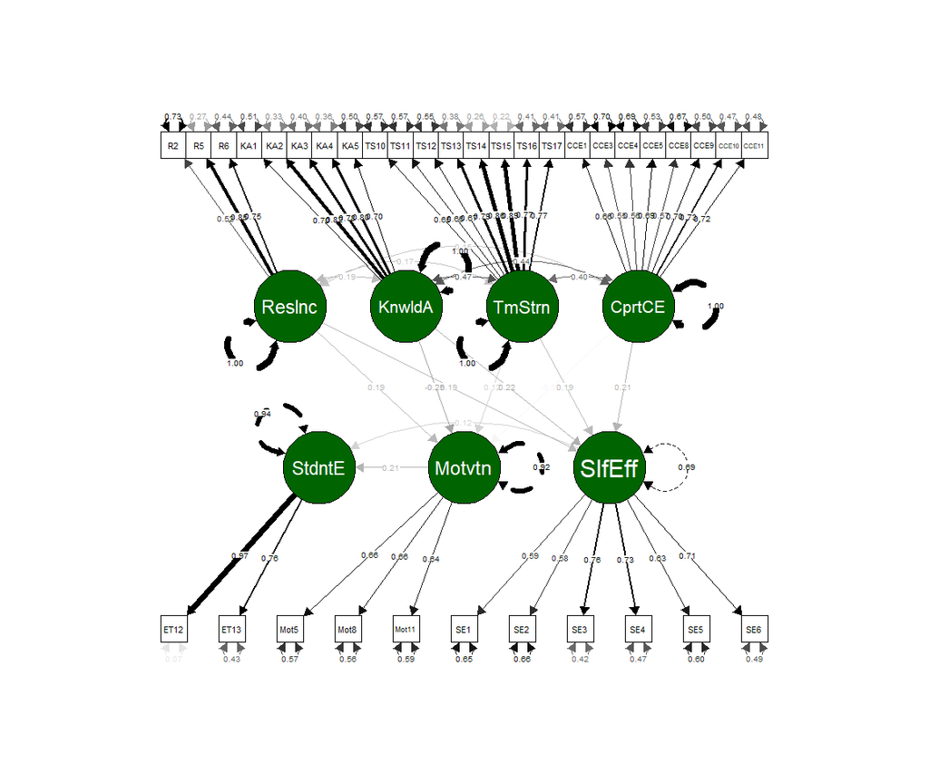

```r
if (correr_SEM) {
  mcs_SEM <- blavInspect(fit.sem, "mcmc")
  mcs_SEM <- as.matrix(mcs_SEM)

  analisar_coluna <- function(col_data, nome_coluna) {
    col_data <- as.numeric(col_data)
    col_data <- col_data[!is.na(col_data)]

    if (length(unique(col_data)) < 2) {
      return(NULL)
    }

    p <- quantile(col_data, probs = c(0.05, 0.25, 0.5, 0.75, 0.95), na.rm = TRUE)
    media <- mean(col_data)
    sd_val <- sd(col_data)

    fit_norm <- fitdist(col_data, "norm")
    fit_lognorm <- tryCatch(fitdist(col_data, "lnorm"), error = function(e) NULL)
    fit_gamma <- tryCatch(fitdist(col_data, "gamma"), error = function(e) NULL)
    fit_exp <- tryCatch(fitdist(col_data, "exp"), error = function(e) NULL)

    fits <- list(norm = fit_norm, lnorm = fit_lognorm, gamma = fit_gamma, exp = fit_exp)
    aic_vals <- sapply(fits, function(f) if (!is.null(f)) f$aic else Inf)
    best_dist <- names(which.min(aic_vals))

    data.frame(
      variavel = nome_coluna,
      p5 = p[1],
      p25 = p[2],
      p50 = p[3],
      p75 = p[4],
      p95 = p[5],
      media = media,
      sd = sd_val,
      melhor_distribuicao = best_dist,
      stringsAsFactors = FALSE
    )
  }

  resultados <- lapply(seq_len(ncol(mcs_SEM)), function(i) {
    analisar_coluna(mcs_SEM[, i], colnames(mcs_SEM)[i])
  })

  resumo_mcs <- do.call(rbind, Filter(Negate(is.null), resultados))
}
```

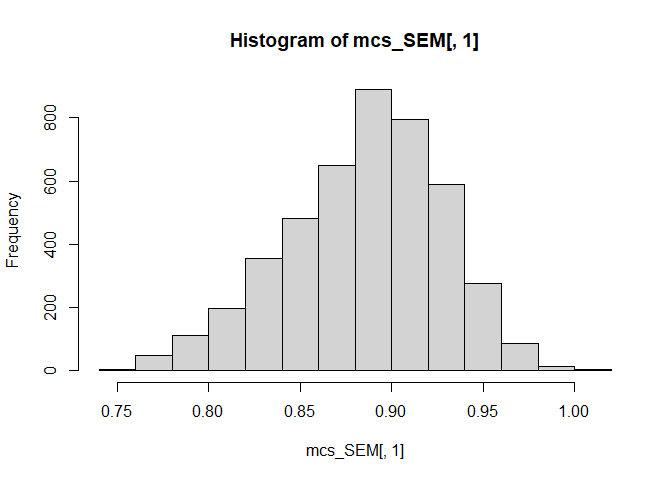

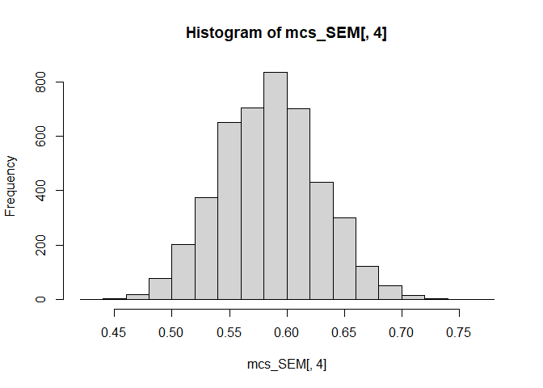

```
## [1] 1
```

```r
if (correr_SEM) {
  dim(mcs_SEM)
  # colnames(mcs_SEM)

  # mean(mcs_SEM[,1])
  # sd(mcs_SEM[,1])

  hist(mcs_SEM[,1]) # dist normal
  hist(mcs_SEM[,4]) # tem dist gamma?

  sum(mcs_SEM[,1] > .74)/nrow(mcs_SEM) # [1] 0.9995556
}
```

```r
if (correr_SEM) {
  resumo_mcs
}
```

|  | variavel | p5 | p25 | p50 | p75 | p95 | media | sd | melhor_distribuicao |
| --- | --- | --- | --- | --- | --- | --- | --- | --- | --- |
| 5% | StudentEthics=~ET12 | 0.8051492241 | 0.857352764 | 0.88980635 | 0.91603698 | 0.94826707 | 0.88511218 | 0.042840188 | norm |
| 5%1 | StudentEthics=~ET13 | 0.6254361117 | 0.660044498 | 0.68615293 | 0.71511580 | 0.76102995 | 0.68854527 | 0.040562688 | lnorm |
| 5%2 | Motivation=~Mot5 | 0.4875458520 | 0.526571559 | 0.55564122 | 0.58568913 | 0.62572561 | 0.55628529 | 0.042758627 | norm |
| 5%3 | Motivation=~Mot8 | 0.5148687030 | 0.554176012 | 0.58512404 | 0.61264863 | 0.65709992 | 0.58508626 | 0.043820804 | gamma |
| 5%4 | Motivation=~Mot11 | 0.5019722017 | 0.541395447 | 0.57096590 | 0.60208498 | 0.64833695 | 0.57262950 | 0.044570383 | gamma |
| 5%5 | SelfEfficacy=~SE1 | 0.3142032419 | 0.336132749 | 0.35191096 | 0.36839044 | 0.39317352 | 0.35244675 | 0.024138826 | gamma |
| 5%6 | SelfEfficacy=~SE2 | 0.3247354818 | 0.350395397 | 0.36847262 | 0.38593692 | 0.41168245 | 0.36831937 | 0.026442870 | norm |
| 5%7 | SelfEfficacy=~SE3 | 0.3933673780 | 0.414280234 | 0.42931151 | 0.44600708 | 0.46906269 | 0.43001077 | 0.023266832 | gamma |
| 5%8 | SelfEfficacy=~SE4 | 0.3679034279 | 0.390719365 | 0.40498490 | 0.41994505 | 0.44170077 | 0.40531543 | 0.022466903 | norm |
| 5%9 | SelfEfficacy=~SE5 | 0.3242500417 | 0.345559585 | 0.36287936 | 0.38119822 | 0.40614261 | 0.36350072 | 0.025693408 | gamma |

[output cut: 76 more lines]

```r
if (correr_SEM) {
  ML_SEM_bs <- blavFitIndices(fit.sem)
  summary(ML_SEM_bs, prob=.95,central.tendency = c("mean","median"))
}
```

|  | EAP | Median | SD | lower | upper |
| --- | --- | --- | --- | --- | --- |
| BRMSEA | 0.07231824 | 0.07229856 | 0.0003540135 | 0.07164006 | 0.07301094 |
| BGammaHat | 0.88377424 | 0.88383145 | 0.0010059691 | 0.88180280 | 0.88569719 |
| adjBGammaHat | 0.83360316 | 0.83368506 | 0.0014402150 | 0.83078070 | 0.83635618 |
| BMc | 0.31642537 | 0.31661218 | 0.0035616931 | 0.30948256 | 0.32328438 |

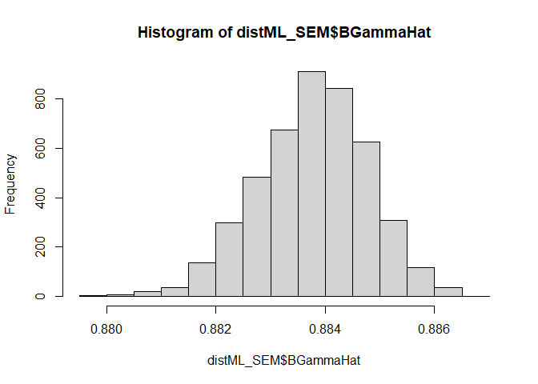

```r
if (correr_SEM) {
  distML_SEM <- data.frame(ML_SEM_bs@indices)
  sum(distML_SEM$BGammaHat > .88)/nrow(distML_SEM) # maior que .88
  hist(distML_SEM$BGammaHat)
}
```

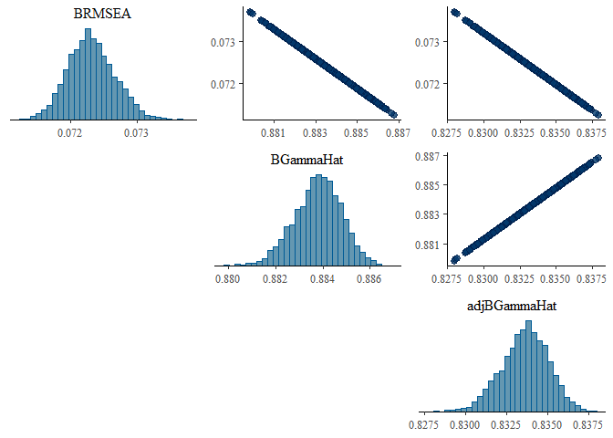

```r
if (correr_SEM) {
  mcmc_pairs(distML_SEM, pars = c("BRMSEA","BGammaHat","adjBGammaHat"), diag_fun =
  "hist")
}
```

#### Tentativa de melhoria com o SEM seguido

```r
if(correr_SEM){
  tic()
  model.sem_fullpurpose <- '
    # measurement model
    StudentEthics =~ ET12 + ET13
    Motivation =~ Mot5 + Mot8 + Mot11
    SelfEfficacy =~ SE1 + SE2 + SE3 + SE4 + SE5 + SE6
    Resilience =~ R5 + R6
    KnowledgeArticulation =~ KA1 + KA2 + KA3 + KA4 + KA5
    TeamStrain =~ TS10 + TS11 + TS12 + TS13 + TS14 + TS15 + TS16 + TS17
    CooperativeClassroomEnvironment =~ CCE1 + CCE5 + CCE10 + CCE11 + CCE16 + CCE17 + CCE18 + CCE19

    # regressions
    Motivation ~ Resilience + KnowledgeArticulation + TeamStrain + CooperativeClassroomEnvironment
    SelfEfficacy ~ Resilience + KnowledgeArticulation + TeamStrain + CooperativeClassroomEnvironment
    StudentEthics ~ Motivation + SelfEfficacy

  '

  fit.sem_fullpurpose <- bcfa(model.sem_fullpurpose, data=df, std.lv=TRUE, n.chains = n_chains,
                   burnin=burn_in, sample=sample_estimate, target = "stan")
  toc()
}
```

```
## Computing post-estimation metrics (including lvs if requested)...
## 2406.21 sec elapsed
```

```r
if(correr_SEM){
  summary(fit.sem_fullpurpose, standardized=TRUE, rsquare=TRUE)
}
```

```
## blavaan 0.5.8 did NOT end normally after 1500 iterations
## ** WARNING ** Estimates below are most likely unreliable
##
##   Estimator                                      BAYES
##   Optimization method                             MCMC
##   Number of model parameters                        84
##
##   Number of observations                           566
##
##   Statistic                                 MargLogLik         PPP
##   Value                                     -16639.494       0.000
##
## Parameter Estimates:
##
##
## Latent Variables:
##                                      Estimate  Post.SD pi.lower pi.upper
##   StudentEthics =~
##     ET12                                0.831    0.077    0.703    0.953
##     ET13                                0.744    0.078    0.622    0.885
##   Motivation =~
##     Mot5                                0.544    0.037    0.474    0.621
##     Mot8                                0.578    0.042    0.507    0.661
##     Mot11                               0.607    0.066    0.493    0.726
##   SelfEfficacy =~
##     SE1                                 0.358    0.022    0.316    0.405
##     SE2                                 0.380    0.025    0.325    0.427
##     SE3                                 0.440    0.021    0.397    0.481
##     SE4                                 0.416    0.022    0.375    0.459
##     SE5                                 0.376    0.022    0.328    0.420
##     SE6                                 0.402    0.022    0.354    0.438
##   Resilience =~
##     R5                                  0.688    0.050    0.585    0.785
##     R6                                  0.573    0.044    0.485    0.663
##   KnowledgeArticulation =~
##     KA1                                 0.476    0.024    0.432    0.530
##     KA2                                 0.529    0.022    0.489    0.578
##     KA3                                 0.486    0.025    0.435    0.533
##     KA4                                 0.511    0.021    0.470    0.555
##     KA5                                 0.458    0.026    0.405    0.498
```

[output cut: 223 more lines]

```
##     TS14              0.755
##     TS15              0.787
##     TS16              0.600
##     TS17              0.587
##     CCE1              0.305
##     CCE5              0.313
##     CCE10             0.287
##     CCE11             0.268
##     CCE16             0.620
##     CCE17             0.622
##     CCE18             0.623
##     CCE19             0.642
##     StudentEthics     0.044
##     Motivation        0.102
##     SelfEfficacy      0.282
```

```r
if(correr_SEM){
  inspect(fit.sem_fullpurpose, what = "std")$lambda
}
```

```
##       StdntE Motvtn SlfEff Reslnc KnwldA TmStrn CprtCE
## ET12   0.906  0.000  0.000  0.000  0.000  0.000  0.000
## ET13   0.816  0.000  0.000  0.000  0.000  0.000  0.000
## Mot5   0.000  0.647  0.000  0.000  0.000  0.000  0.000
## Mot8   0.000  0.663  0.000  0.000  0.000  0.000  0.000
## Mot11  0.000  0.679  0.000  0.000  0.000  0.000  0.000
## SE1    0.000  0.000  0.587  0.000  0.000  0.000  0.000
## SE2    0.000  0.000  0.582  0.000  0.000  0.000  0.000
## SE3    0.000  0.000  0.762  0.000  0.000  0.000  0.000
## SE4    0.000  0.000  0.737  0.000  0.000  0.000  0.000
## SE5    0.000  0.000  0.639  0.000  0.000  0.000  0.000
## SE6    0.000  0.000  0.730  0.000  0.000  0.000  0.000
## R5     0.000  0.000  0.000  0.858  0.000  0.000  0.000
## R6     0.000  0.000  0.000  0.754  0.000  0.000  0.000
## KA1    0.000  0.000  0.000  0.000  0.701  0.000  0.000
## KA2    0.000  0.000  0.000  0.000  0.814  0.000  0.000
## KA3    0.000  0.000  0.000  0.000  0.781  0.000  0.000
## KA4    0.000  0.000  0.000  0.000  0.800  0.000  0.000
## KA5    0.000  0.000  0.000  0.000  0.716  0.000  0.000
## TS10   0.000  0.000  0.000  0.000  0.000  0.662  0.000
## TS11   0.000  0.000  0.000  0.000  0.000  0.661  0.000
## TS12   0.000  0.000  0.000  0.000  0.000  0.666  0.000
## TS13   0.000  0.000  0.000  0.000  0.000  0.798  0.000
## TS14   0.000  0.000  0.000  0.000  0.000  0.869  0.000
## TS15   0.000  0.000  0.000  0.000  0.000  0.887  0.000
## TS16   0.000  0.000  0.000  0.000  0.000  0.774  0.000
## TS17   0.000  0.000  0.000  0.000  0.000  0.766  0.000
## CCE1   0.000  0.000  0.000  0.000  0.000  0.000  0.552
## CCE5   0.000  0.000  0.000  0.000  0.000  0.000  0.560
## CCE10  0.000  0.000  0.000  0.000  0.000  0.000  0.535
## CCE11  0.000  0.000  0.000  0.000  0.000  0.000  0.517
## CCE16  0.000  0.000  0.000  0.000  0.000  0.000  0.788
## CCE17  0.000  0.000  0.000  0.000  0.000  0.000  0.789
## CCE18  0.000  0.000  0.000  0.000  0.000  0.000  0.789
## CCE19  0.000  0.000  0.000  0.000  0.000  0.000  0.801
```

```r
if(correr_SEM){
  semPaths(fit.sem_fullpurpose,
           what = "std",
           layout = "tree",
           edge.label.cex = 0.4,
           sizeMan = 3,
           sizeLat = 8,
           nCharNodes = 6,
           residuals = TRUE,
           intercepts = FALSE,
           optimizeLatRes = TRUE,
           edge.color = "black",
           color = list(lat = "darkgreen", man = "white"),
           mar = c(6, 6, 6, 6)
  )
}
```

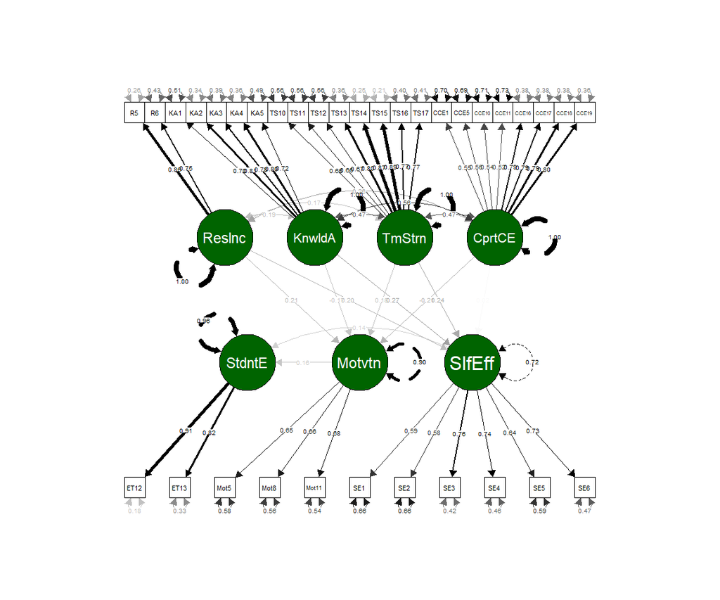

#### Comparação entre os dois SEM

```r
if(correr_SEM){
  blavCompare(fit.sem_FAauthors, fit.sem_meanOUR)
  # blavCompare(fit.sem, fit.sem_FAauthors) # não comparável
  # blavCompare(fit.sem_fullpurpose, fit.sem_FAauthors) # não comparável
  blavCompare(fit.sem, fit.sem_fullpurpose)
}
```

```
##
## WAIC estimates:
##  object1:  3351.091
##  object2:  3351.458
##
##  ELPD difference & SE:
##    -0.183    0.133
##
## LOO estimates:
##  object1:  3351.298
##  object2:  3351.983
##
##  ELPD difference & SE:
##    -0.342    0.383
##
## Laplace approximation to the log-Bayes factor
## (experimental; positive values favor object1):    0.009
```

```
##
## WAIC estimates:
##  object1:  35080.812
##  object2:  32753.567
##
##  ELPD difference & SE:
##  -1163.623  144.132
##
## LOO estimates:
##  object1:  35074.293
##  object2:  32740.437
##
##  ELPD difference & SE:
##  -1166.928  143.302
##
## Laplace approximation to the log-Bayes factor
## (experimental; positive values favor object1): -1171.931
```

### 4- SEM com priors

#### Priors para lambda, beta e ET12 e ET13

Estudo de algumas priors baseado nos valores de loadings obtidos e os do paper. Veremos algumas distribuições conhecidas e tentar adaptar o valor do lambda para uma normal porque a função `dpriors` tem limitações em quais priors pode replicar.

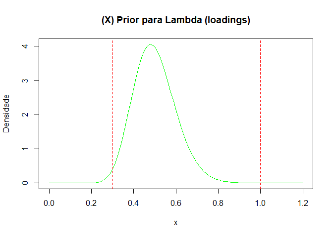

```r
curve(dgamma(x, 25, 50), from=0, to=1.2, main="(X) Prior para Lambda (loadings)", col = "green", ylab="Densidade")
abline(v=c(0.3, 1), col="red", lty=2)
```

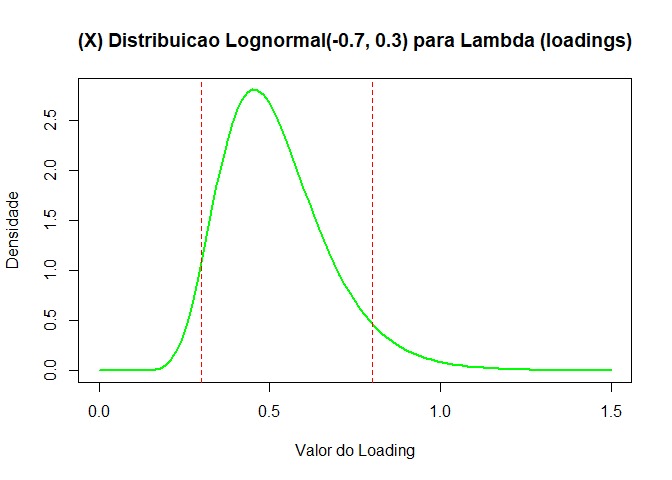

```r
curve(dlnorm(x, meanlog = -0.7, sdlog = 0.3),
      from = 0, to = 1.5,
      col = "green", lwd = 2,
      ylab = "Densidade", xlab = "Valor do Loading",
      main = "(X) Distribuicao Lognormal(-0.7, 0.3) para Lambda (loadings)")
abline(v = c(0.3, 0.8), col = "red", lty = 2)
```

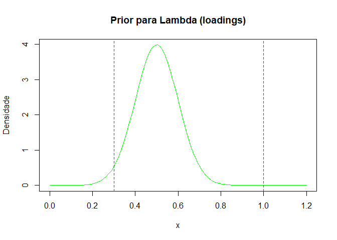

```r
curve(dnorm(x, 0.5, 0.1), from=0, to=1.2, main="Prior para Lambda (loadings)", col = "green", ylab="Densidade")
abline(v=c(0.3, 1), col="red", lty=2)
```

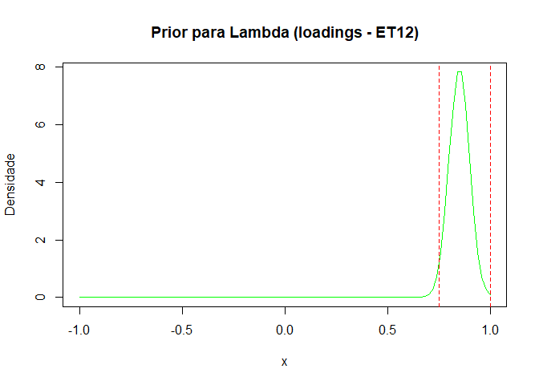

```r
curve(c(dnorm(x, 0.85, 0.05)), from=-1, to=1, col = "green", main="Prior para Lambda (loadings - ET12)", ylab="Densidade")
abline(v=c(0.75, 1.0), col="red", lty=2)
```

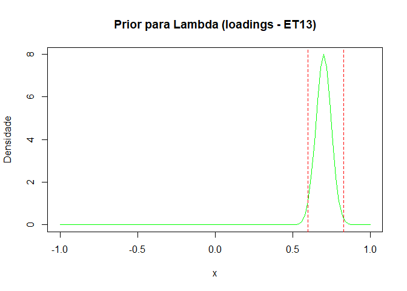

```r
curve(c(dnorm(x, 0.7, 0.05)), from=-1, to=1, col = "green", main="Prior para Lambda (loadings - ET13)", ylab="Densidade")
abline(v=c(0.6, 0.83), col="red", lty=2)
```

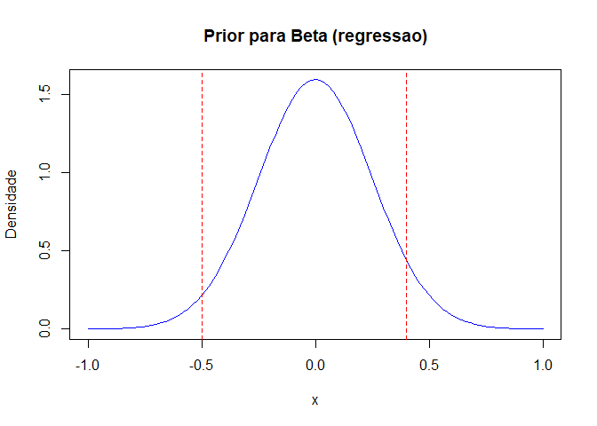

```r
curve(dnorm(x, 0, 0.25), from=-1, to=1,col = "blue", main="Prior para Beta (regressao)", ylab="Densidade")
abline(v=c(-0.5, 0.4), col="red", lty=2)
```

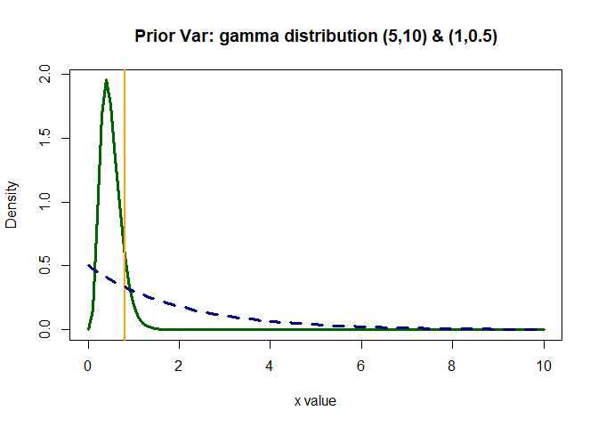

```r
plot(seq(0,10,.1), dgamma(seq(0,10,.1),5, 10), type="l", lty=1, lwd = 3, xlab="x value",
     ylab="Density", main="Prior Var: gamma distribution (5,10) & (1,0.5)", col = "darkgreen")
abline(v=.8, col="orange", lwd=2)
lines(seq(0,10,.1), dgamma(seq(0,10,.1),1,0.5), col = "darkblue", lwd = 3, lty = 2)
```

```r
# individual params
n_chains <- 3 # 3
burn_in <- 500 # 200
sample_estimate <- 1500 #1000
```

```r
if(correr_SEM_cpriors){
  tic()
  dp <- dpriors(lambda = "normal(0.5, 0.1)", # semelhante "gamma(25, 50)"; nao conchigo utilizar gamma :(
                beta   = "normal(0, 0.25)" # talvez aumentar um pouco mais sd (cauda mais longa)
                #, theta  = "gamma(5, 10)" # variances
                )
  model.sem_priors <- '
    # measurement model
    StudentEthics =~ prior("normal(0.85, 0.05)")*ET12 + prior("normal(0.7, 0.05)")*ET13
    Motivation =~ Mot5 + Mot8 + Mot11
    SelfEfficacy =~ SE1 + SE2 + SE3 + SE4 + SE5 + SE6
    Resilience =~ R2 + R5 + R6
    KnowledgeArticulation =~ KA1 + KA2 + KA3 + KA4 + KA5
    TeamStrain =~ TS10 + TS11 + TS12 + TS13 + TS14 + TS15 + TS16 + TS17
    CooperativeClassroomEnvironment =~ CCE1 + CCE3 + CCE4 + CCE5 + CCE8 + CCE9 + CCE10 + CCE11

    # regressions
    Motivation ~ Resilience + KnowledgeArticulation + TeamStrain + CooperativeClassroomEnvironment
    SelfEfficacy ~ Resilience + KnowledgeArticulation + TeamStrain + CooperativeClassroomEnvironment
    StudentEthics ~ Motivation + SelfEfficacy

  '

  fit.sem_priors <- bcfa(model.sem_priors, data=df, std.lv=TRUE, n.chains = n_chains,
                   burnin=burn_in, sample=sample_estimate, target = "stan", dp = dp)
  toc()
}
```

```
## Computing post-estimation metrics (including lvs if requested)...
## 261.36 sec elapsed
```

```r
if(correr_SEM_cpriors){
  summary(fit.sem_priors, standardized=TRUE, rsquare=TRUE)
}
```

```
## blavaan 0.5.8 ended normally after 1500 iterations
##
##   Estimator                                      BAYES
##   Optimization method                             MCMC
##   Number of model parameters                        86
##
##   Number of observations                           566
##
##   Statistic                                 MargLogLik         PPP
##   Value                                     -17624.741       0.000
##
## Parameter Estimates:
##
##
## Latent Variables:
##                                      Estimate  Post.SD pi.lower pi.upper
##   StudentEthics =~
##     ET12                                0.872    0.036    0.799    0.937
##     ET13                                0.691    0.034    0.628    0.761
##   Motivation =~
##     Mot5                                0.548    0.039    0.472    0.626
##     Mot8                                0.573    0.040    0.495    0.653
##     Mot11                               0.561    0.040    0.482    0.640
##   SelfEfficacy =~
##     SE1                                 0.370    0.025    0.322    0.419
##     SE2                                 0.387    0.027    0.336    0.441
##     SE3                                 0.445    0.023    0.401    0.490
##     SE4                                 0.421    0.023    0.378    0.468
##     SE5                                 0.381    0.024    0.335    0.429
##     SE6                                 0.401    0.022    0.360    0.444
##   Resilience =~
##     R2                                  0.413    0.031    0.352    0.476
##     R5                                  0.661    0.033    0.596    0.727
##     R6                                  0.561    0.030    0.501    0.621
##   KnowledgeArticulation =~
##     KA1                                 0.478    0.025    0.429    0.528
##     KA2                                 0.528    0.023    0.484    0.573
##     KA3                                 0.482    0.022    0.440    0.527
##     KA4                                 0.513    0.023    0.470    0.559
##     KA5                                 0.450    0.024    0.404    0.497
```

[output cut: 227 more lines]

```
##     TS14              0.738
##     TS15              0.781
##     TS16              0.595
##     TS17              0.592
##     CCE1              0.438
##     CCE3              0.309
##     CCE4              0.327
##     CCE5              0.479
##     CCE8              0.336
##     CCE9              0.499
##     CCE10             0.538
##     CCE11             0.525
##     StudentEthics     0.055
##     Motivation        0.069
##     SelfEfficacy      0.283
```

```r
if(correr_SEM_cpriors){
  semPaths(fit.sem_priors,
           what = "std",
           layout = "tree",
           edge.label.cex = 1.0,
           sizeMan = 10,
           sizeLat = 8,
           nCharNodes = 6,
           residuals = TRUE,
           intercepts = FALSE,
           optimizeLatRes = TRUE,
           edge.color = "black",
           color = list(lat = "darkgreen", man = "lightblue"),
           mar = c(6, 6, 6, 6)
  )
}
```

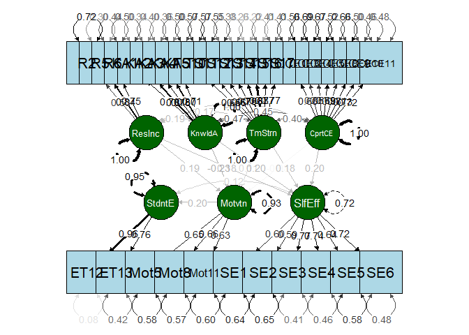

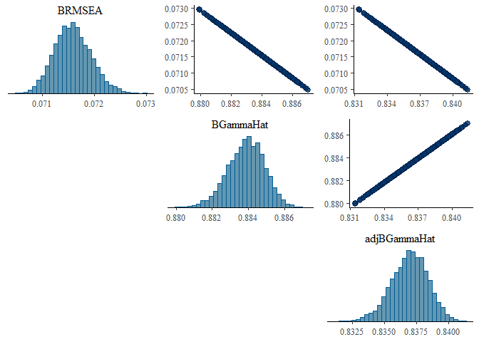

```r
if(correr_SEM_cpriors){
  ML_SEMpriors_bs <- blavFitIndices(fit.sem_priors)
  summary(ML_SEMpriors_bs, prob=.95,central.tendency = c("mean","median"))
  distML_SEMpriors <- data.frame(ML_SEMpriors_bs@indices)
  mcmc_pairs(distML_SEMpriors, pars = c("BRMSEA","BGammaHat","adjBGammaHat"), diag_fun =
    "hist")
}
```

```r
if(correr_SEM_cpriors){
  blavCompare(fit.sem_priors, fit.sem)
  (fits_SEModels <- cbind(fitMeasures(fit.sem_priors), fitMeasures(fit.sem)))
}
```

```
##
## WAIC estimates:
##  object1:  35072.063
##  object2:  35080.812
##
##  ELPD difference & SE:
##    -4.375    2.715
##
## LOO estimates:
##  object1:  35065.666
##  object2:  35074.293
##
##  ELPD difference & SE:
##    -4.313    2.627
##
## Laplace approximation to the log-Bayes factor
## (experimental; positive values favor object1):  186.684
```

```
##                    [,1]         [,2]
## npar           86.00000     86.00000
## logl       -17399.00580 -17397.64169
## ppp             0.00000      0.00000
## bic         35342.97861  35340.25040
## dic         34960.18302  34965.31870
## p_dic          81.08571     85.01765
## waic        35072.06283  35080.81209
## p_waic        184.51524    192.97291
## se_waic       710.62730    711.03071
## looic       35065.62616  35074.77474
## p_loo         181.29691    189.95423
## se_loo        708.27043    709.00094
## margloglik -17624.74083 -17811.42438
```

#### Priors com regressão 0

```r
if(correr_SEM_cpriors){
  tic()
  model.sem_priors_reg0 <- '
    # measurement model
    StudentEthics =~ ET12 + ET13
    Motivation =~ Mot5 + Mot8 + Mot11
    SelfEfficacy =~ SE1 + SE2 + SE3 + SE4 + SE5 + SE6
    Resilience =~ R2 + R5 + R6
    KnowledgeArticulation =~ KA1 + KA2 + KA3 + KA4 + KA5
    TeamStrain =~ TS10 + TS11 + TS12 + TS13 + TS14 + TS15 + TS16 + TS17
    CooperativeClassroomEnvironment =~ CCE1 + CCE3 + CCE4 + CCE5 + CCE8 + CCE9 + CCE10 + CCE11

    # regressions
    Motivation ~ Resilience + KnowledgeArticulation + TeamStrain + CooperativeClassroomEnvironment
    SelfEfficacy ~ Resilience + KnowledgeArticulation + TeamStrain + prior("normal(0, 0.0001)")*CooperativeClassroomEnvironment
    StudentEthics ~ Motivation + SelfEfficacy

  '

  fit.sem_priors_reg0 <- bcfa(model.sem_priors_reg0, data=df, std.lv=TRUE, n.chains = n_chains,
                   burnin=burn_in, sample=sample_estimate, target = "stan")
  toc()
}
```

```
## Computing post-estimation metrics (including lvs if requested)...
## 5210.97 sec elapsed
```

```r
if(correr_SEM_cpriors){
  summary(fit.sem_priors_reg0, standardized=TRUE, rsquare=TRUE)
}
```

```
## blavaan 0.5.8 ended normally after 1500 iterations
##
##   Estimator                                      BAYES
##   Optimization method                             MCMC
##   Number of model parameters                        86
##
##   Number of observations                           566
##
##   Statistic                                 MargLogLik         PPP
##   Value                                     -17812.479       0.000
##
## Parameter Estimates:
##
##
## Latent Variables:
##                                      Estimate  Post.SD pi.lower pi.upper
##   StudentEthics =~
##     ET12                                0.860    0.067    0.693    0.957
##     ET13                                0.712    0.067    0.616    0.887
##   Motivation =~
##     Mot5                                0.556    0.041    0.475    0.638
##     Mot8                                0.585    0.044    0.501    0.673
##     Mot11                               0.572    0.046    0.482    0.662
##   SelfEfficacy =~
##     SE1                                 0.360    0.026    0.312    0.411
##     SE2                                 0.375    0.028    0.320    0.429
##     SE3                                 0.436    0.023    0.391    0.483
##     SE4                                 0.414    0.023    0.367    0.461
##     SE5                                 0.372    0.025    0.324    0.421
##     SE6                                 0.394    0.022    0.352    0.439
##   Resilience =~
##     R2                                  0.407    0.034    0.343    0.475
##     R5                                  0.680    0.036    0.611    0.750
##     R6                                  0.567    0.034    0.503    0.633
##   KnowledgeArticulation =~
##     KA1                                 0.477    0.027    0.425    0.530
##     KA2                                 0.529    0.024    0.484    0.577
##     KA3                                 0.480    0.024    0.435    0.527
##     KA4                                 0.513    0.024    0.467    0.561
##     KA5                                 0.447    0.025    0.399    0.496
```

[output cut: 227 more lines]

```
##     TS14              0.738
##     TS15              0.782
##     TS16              0.595
##     TS17              0.591
##     CCE1              0.432
##     CCE3              0.297
##     CCE4              0.313
##     CCE5              0.470
##     CCE8              0.323
##     CCE9              0.498
##     CCE10             0.537
##     CCE11             0.524
##     StudentEthics     0.056
##     Motivation        0.076
##     SelfEfficacy      0.283
```

```r
if(correr_SEM_cpriors){
  semPaths(fit.sem_priors_reg0,
           what = "std",
           layout = "tree",
           edge.label.cex = 1.0,
           sizeMan = 10,
           sizeLat = 8,
           nCharNodes = 6,
           residuals = TRUE,
           intercepts = FALSE,
           optimizeLatRes = TRUE,
           edge.color = "black",
           color = list(lat = "darkgreen", man = "lightblue"),
           mar = c(6, 6, 6, 6)
  )
}
```

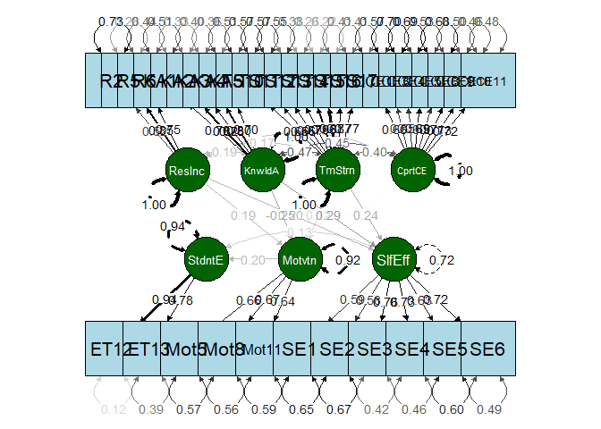

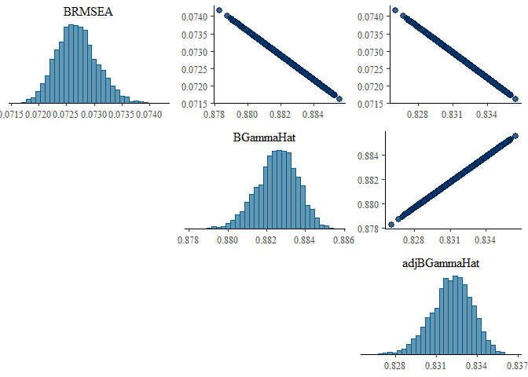

```r
if(correr_SEM_cpriors){
  ML_SEMpriors0_bs <- blavFitIndices(fit.sem_priors_reg0)
  summary(ML_SEMpriors0_bs, prob=.95,central.tendency = c("mean","median"))
  distML_SEMpriors0 <- data.frame(ML_SEMpriors0_bs@indices)
  mcmc_pairs(distML_SEMpriors0, pars = c("BRMSEA","BGammaHat","adjBGammaHat"), diag_fun =
    "hist")
}
```

```r
if(correr_SEM_cpriors){
  blavCompare(fit.sem_priors, fit.sem_priors_reg0)
  (fits_SEModels <- cbind(fitMeasures(fit.sem_priors), fitMeasures(fit.sem_priors_reg0)))
}
```

```
##
## WAIC estimates:
##  object1:  35072.063
##  object2:  35096.408
##
##  ELPD difference & SE:
##   -12.173    6.977
##
## LOO estimates:
##  object1:  35065.666
##  object2:  35089.294
##
##  ELPD difference & SE:
##   -11.814    6.758
##
## Laplace approximation to the log-Bayes factor
## (experimental; positive values favor object1):  187.738
```

```
##                    [,1]         [,2]
## npar           86.00000     86.00000
## logl       -17399.00580 -17405.77381
## ppp             0.00000      0.00000
## bic         35342.97861  35356.51463
## dic         34960.18302  34980.25593
## p_dic          81.08571     84.35415
## waic        35072.06283  35096.40812
## p_waic        184.51524    192.73075
## se_waic       710.62730    714.72846
## looic       35065.62616  35089.27961
## p_loo         181.29691    189.16650
## se_loo        708.27043    712.01177
## margloglik -17624.74083 -17812.47928
```

#### Priors com todas priors

```r
if(correr_SEM_cpriors){
  tic()
  dp <- dpriors(lambda = "normal(0.5, 0.1)", # semelhante "gamma(25, 50)"; nao conchigo utilizar gamma :(
                beta   = "normal(0, 0.25)" # talvez aumentar um pouco mais sd (cauda mais longa)
                #, theta  = "gamma(5, 10)" # variances
                )
  model.sem_priors_all <- '
    # measurement model
    StudentEthics =~ prior("normal(0.85, 0.05)")*ET12 + prior("normal(0.7, 0.05)")*ET13
    Motivation =~ Mot5 + Mot8 + Mot11
    SelfEfficacy =~ SE1 + SE2 + SE3 + SE4 + SE5 + SE6
    Resilience =~ R2 + R5 + R6
    KnowledgeArticulation =~ KA1 + KA2 + KA3 + KA4 + KA5
    TeamStrain =~ TS10 + TS11 + TS12 + TS13 + TS14 + TS15 + TS16 + TS17
    CooperativeClassroomEnvironment =~ CCE1 + CCE3 + CCE4 + CCE5 + CCE8 + CCE9 + CCE10 + CCE11

    # regressions
    Motivation ~ Resilience + KnowledgeArticulation + TeamStrain + CooperativeClassroomEnvironment
    SelfEfficacy ~ Resilience + KnowledgeArticulation + TeamStrain + prior("normal(0, 0.0001)")*CooperativeClassroomEnvironment
    StudentEthics ~ Motivation + SelfEfficacy

  '

  fit.sem_priors_all <- bcfa(model.sem_priors_all, data=df, std.lv=TRUE, n.chains = n_chains,
                   burnin=burn_in, sample=sample_estimate, target = "stan", dp = dp)
  toc()
}
```

```
## Computing post-estimation metrics (including lvs if requested)...
## 6198.18 sec elapsed
```

```r
if(correr_SEM_cpriors){
  summary(fit.sem_priors_all, standardized=TRUE, rsquare=TRUE)
}
```

```
## blavaan 0.5.8 ended normally after 1500 iterations
##
##   Estimator                                      BAYES
##   Optimization method                             MCMC
##   Number of model parameters                        86
##
##   Number of observations                           566
##
##   Statistic                                 MargLogLik         PPP
##   Value                                     -17630.111       0.000
##
## Parameter Estimates:
##
##
## Latent Variables:
##                                      Estimate  Post.SD pi.lower pi.upper
##   StudentEthics =~
##     ET12                                0.870    0.038    0.789    0.936
##     ET13                                0.694    0.036    0.628    0.768
##   Motivation =~
##     Mot5                                0.548    0.039    0.474    0.627
##     Mot8                                0.574    0.039    0.499    0.652
##     Mot11                               0.562    0.041    0.483    0.643
##   SelfEfficacy =~
##     SE1                                 0.376    0.025    0.327    0.428
##     SE2                                 0.393    0.027    0.340    0.448
##     SE3                                 0.450    0.023    0.405    0.497
##     SE4                                 0.429    0.023    0.386    0.476
##     SE5                                 0.388    0.025    0.338    0.437
##     SE6                                 0.409    0.023    0.365    0.454
##   Resilience =~
##     R2                                  0.413    0.033    0.352    0.477
##     R5                                  0.661    0.033    0.598    0.725
##     R6                                  0.562    0.031    0.503    0.623
##   KnowledgeArticulation =~
##     KA1                                 0.478    0.026    0.429    0.529
##     KA2                                 0.529    0.023    0.483    0.574
##     KA3                                 0.481    0.023    0.438    0.526
##     KA4                                 0.512    0.024    0.467    0.559
##     KA5                                 0.449    0.024    0.403    0.497
```

[output cut: 227 more lines]

```
##     TS14              0.738
##     TS15              0.781
##     TS16              0.596
##     TS17              0.592
##     CCE1              0.438
##     CCE3              0.308
##     CCE4              0.325
##     CCE5              0.477
##     CCE8              0.334
##     CCE9              0.500
##     CCE10             0.541
##     CCE11             0.527
##     StudentEthics     0.054
##     Motivation        0.069
##     SelfEfficacy      0.256
```

```r
if(correr_SEM_cpriors){
  semPaths(fit.sem_priors_all,
           what = "std",
           layout = "tree",
           edge.label.cex = 1.0,
           sizeMan = 10,
           sizeLat = 8,
           nCharNodes = 6,
           residuals = TRUE,
           intercepts = FALSE,
           optimizeLatRes = TRUE,
           edge.color = "black",
           color = list(lat = "darkgreen", man = "lightblue"),
           mar = c(6, 6, 6, 6)
  )
}
```

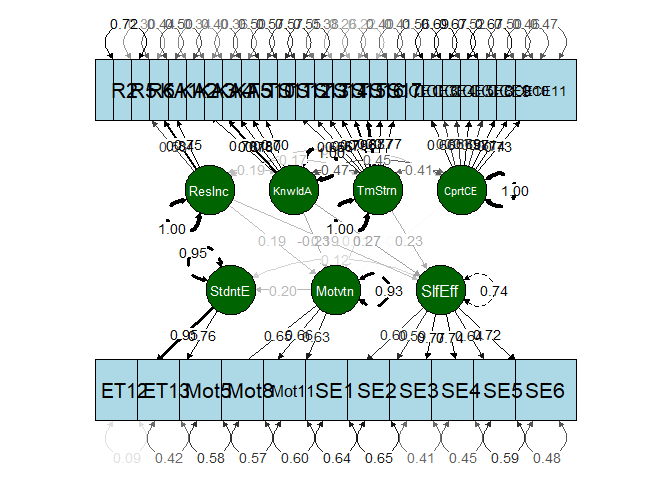

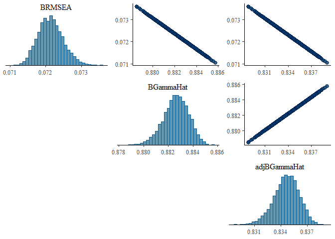

```r
if(correr_SEM_cpriors){
  ML_SEMpriorsall_bs <- blavFitIndices(fit.sem_priors_all)
  summary(ML_SEMpriorsall_bs, prob=.95,central.tendency = c("mean","median"))
  distML_SEMpriorsall <- data.frame(ML_SEMpriorsall_bs@indices)
  mcmc_pairs(distML_SEMpriorsall, pars = c("BRMSEA","BGammaHat","adjBGammaHat"), diag_fun =
    "hist")
}
```

```r
if(correr_SEM_cpriors){
  blavCompare(fit.sem_priors, fit.sem_priors_reg0)
  blavCompare(fit.sem_priors, fit.sem_priors_all)
  (fits_SEModels <- cbind(fitMeasures(fit.sem), fitMeasures(fit.sem_priors), fitMeasures(fit.sem_priors_reg0), fitMeasures(fit.sem_priors_all)))
}
```

```
##
## WAIC estimates:
##  object1:  35072.063
##  object2:  35096.408
##
##  ELPD difference & SE:
##   -12.173    6.977
##
## LOO estimates:
##  object1:  35065.666
##  object2:  35089.294
##
##  ELPD difference & SE:
##   -11.814    6.758
##
## Laplace approximation to the log-Bayes factor
## (experimental; positive values favor object1):  187.738
```

```
##
## WAIC estimates:
##  object1:  35072.063
##  object2:  35088.179
##
##  ELPD difference & SE:
##    -8.058    6.136
##
## LOO estimates:
##  object1:  35065.666
##  object2:  35081.933
##
##  ELPD difference & SE:
##    -8.133    6.367
##
## Laplace approximation to the log-Bayes factor
## (experimental; positive values favor object1):    5.370
```

```
##                    [,1]         [,2]         [,3]         [,4]
## npar           86.00000     86.00000     86.00000     86.00000
## logl       -17397.64169 -17399.00580 -17405.77381 -17406.87723
## ppp             0.00000      0.00000      0.00000      0.00000
## bic         35340.25040  35342.97861  35356.51463  35358.72147
## dic         34965.31870  34960.18302  34980.25593  34976.11803
## p_dic          85.01765     81.08571     84.35415     81.18179
## waic        35080.81209  35072.06283  35096.40812  35088.17865
## p_waic        192.97291    184.51524    192.73075    185.98617
## se_waic       711.03071    710.62730    714.72846    712.78064
## looic       35074.77474  35065.62616  35089.27961  35081.80942
## p_loo         189.95423    181.29691    189.16650    182.80156
## se_loo        709.00094    708.27043    712.01177    710.59093
## margloglik -17811.42438 -17624.74083 -17812.47928 -17630.11059
```